# Compare and overview of the estimated overlap between butterflies and hosts using results from hmsc

Libraries:

```r
library(here)
library(tidyverse)
library(ggplot2)
theme_set(theme_minimal())
```

Read calculated overlaps

```r
# Elena's recalculation using Clarke data
ovelap_current <- read_csv(here("hmsc/output/butterfly_range_overlap_current_non_spat.csv"))

# Jussi's using previous interaction data
overlap_current_Jussi <- read_csv('/Users/elqu2194/Library/CloudStorage/OneDrive-Sverigeslantbruksuniversitet/Archivos de Mariana Pires Braga - EvonetsLab/Projects/SwissLeps/HMSC/nonspatial/range_overlap_current_non_spat.csv')
```

**Compare species with information:**

No. of species with information in the hmsc:

```r
nrow(overlap_current_Jussi) # 163 species (so 11 more species in Jussi's data)
```

```
[1] 163
```

No. of species with information in interaction data (Clarke):

```r
nrow(ovelap_current) # 152 species
```

```
[1] 152
```

Species with information in the interaction data (Clarke) but not in the hmsc:

```r
setdiff(ovelap_current$Species, overlap_current_Jussi$Species)
```

```
[1] "Satyrium_w.album"  "Polygonia_c.album"
```

HMSC results miss information for *Satyrium_w.album* *Polygonia_c.album* (prob. because of the dot in the name they were lost)

Species with information in the hmsc but not in the interaction data (Clarke):

```r
setdiff(overlap_current_Jussi$Species, ovelap_current$Species)
```

```
 [1] "Pyrgus_onopordi"     "Leptidea_sinapis"    "Colias_hyale"
 [4] "Pontia_edusa"        "Pieris_rapae"        "Brenthis_daphne"
 [7] "Argynnis_pandora"    "Boloria_thore"       "Melitaea_asteria"
[10] "Pararge_aegeria"     "Coenonympha_arcania" "Chazara_briseis"
[13] "Pyronia_tithonus"
```

New overlap data misses 13 butterfly species (because either not present in Clarke interaction data or they dont have good evidence information).

## Correlate butterfly range overlap values between the two datasets

Considering only common species (so, 150 species)

```r
combined_overlap <- ovelap_current |>
  inner_join(overlap_current_Jussi, by = c("Species" = "Species"))
```

Compare species range (this shouldn’t have changed, but it did, dont know why!!)

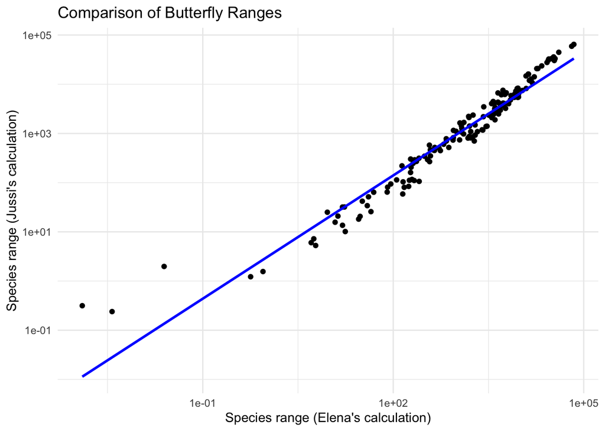

```r
ggplot(combined_overlap, aes(x = Range.x, y = Range.y)) +
  geom_point() +
  geom_smooth(method = "lm", se = FALSE, color = "blue") +
  labs(x = "Species range (Elena's calculation)", y = "Species range (Jussi's calculation)") +
  ggtitle("Comparison of Butterfly Ranges") +
  scale_x_log10() +
  scale_y_log10()
```

Host range

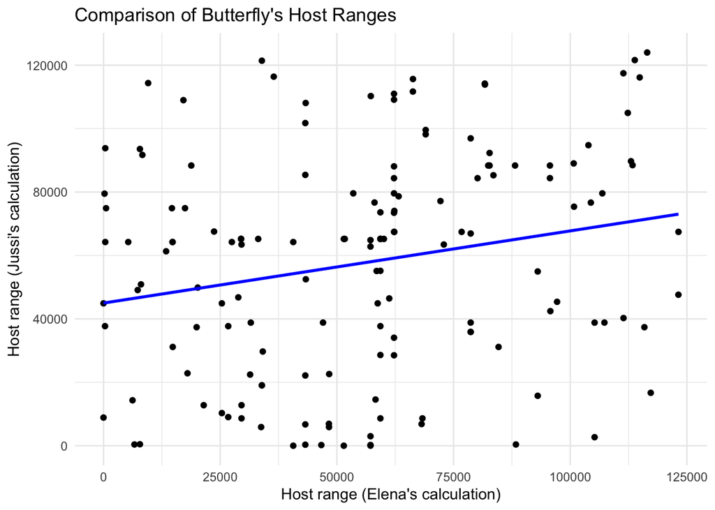

```r
ggplot(combined_overlap, aes(x = Range_hosts.x, y = Range_hosts.y)) +
  geom_point() +
  geom_smooth(method = "lm", se = FALSE, color = "blue") +
  labs(x = "Host range (Elena's calculation)", y = "Host range (Jussi's calculation)") +
  ggtitle("Comparison of Butterfly's Host Ranges")
```

# Overlap with host plants

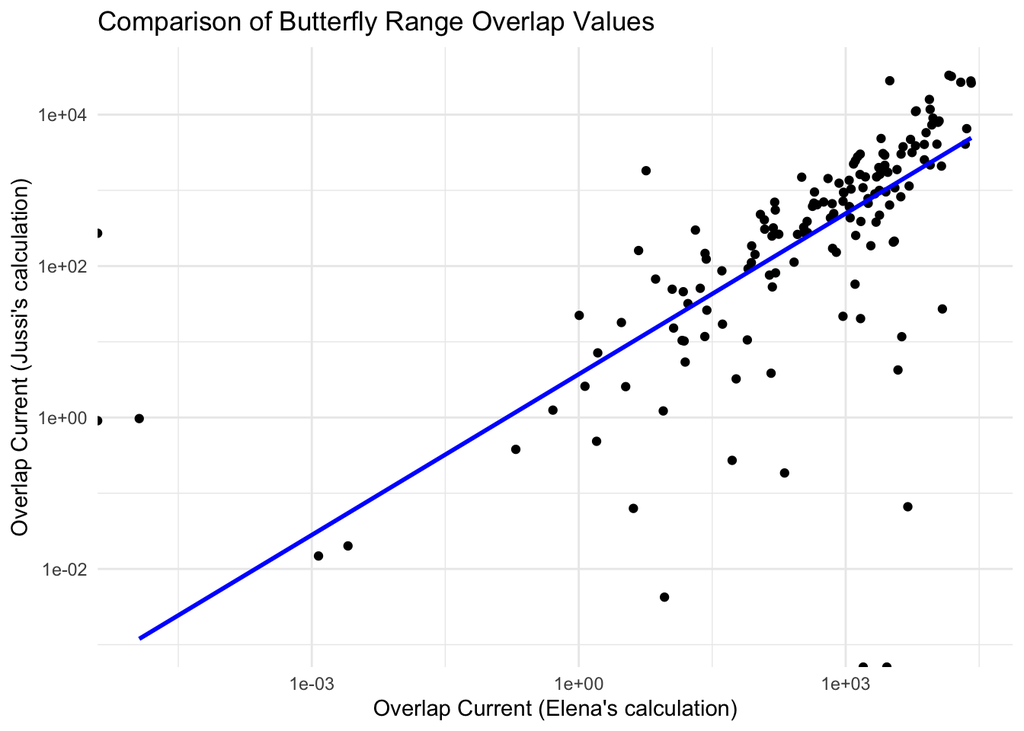

```r
ggplot(combined_overlap, aes(x = Overlap_hosts.x, y = Overlap_hosts.y)) +
  geom_point() +
  geom_smooth(method = "lm", se = FALSE, color = "blue") +
  labs(x = "Overlap Current (Elena's calculation)", y = "Overlap Current (Jussi's calculation)") +
  ggtitle("Comparison of Butterfly Range Overlap Values") +
  scale_x_log10() +
  scale_y_log10()
```

Now, thinking on reasons why some overlap values are zero in the new overlap data (Elena’s): were there plant genera in Clarke interaction dataset which had not range data in the hmsc?

```r
# Load Jussi's hmsc predicted ranges (raw data) and the interaction matrix
pred_current = read.csv(here('hmsc/output/pred_all_mean_current_non_spat_no_hpc.csv'))
int_matrix = read.csv(here('interaction/data/Swiss_web_gen_strict.csv'))
```

Plants with interaction info but no hmsc data (n = 45!!)

```r
sort(setdiff(int_matrix$X, colnames(pred_current)[-c(1:165)]))
```

```
 [1] "Aegopodium"    "Agrimonia"     "Alyssoides"    "Andromeda"
 [5] "Androsace"     "Anethum"       "Apium"         "Arctium"
 [9] "Aria"          "Aubrieta"      "Avenula"       "Barbarea"
[13] "Betonica"      "Betula"        "Bistorta"      "Carlina"
[17] "Comarum"       "Daucus"        "Diplotaxis"    "Dryas"
[21] "Empetrum"      "Erucastrum"    "Eryngium"      "Fourraea"
[25] "Gentianella"   "Geum"          "Hedysarum"     "Hippophae"
[29] "Hylotelephium" "Kernera"       "Laserpitium"   "Leontopodium"
[33] "Marrubium"     "Mutarda"       "Nasturtium"    "Noccaea"
[37] "Onopordum"     "Origanum"      "Ostrya"        "Petrosedum"
[41] "Petroselinum"  "Silaum"        "Sisymbrium"    "Teesdalia"
[45] "Tussilago"
```

No. of plant genera in the hmsc data:

```r
length(colnames(pred_current)[-c(1:165)]) #plant genera in hmsc data
```

```
[1] 163
```

Plants with hmsc data but no observed interaction info (**OBS!:** all these genera except for *Vulpia* are present in the European metaweb, so they are potential hosts for some butterflies, but not reported with certainty in Switzerland):

```r
sort(setdiff(colnames(pred_current)[-c(1:165)], int_matrix$X))
```

```
 [1] "Aira"          "Alchemilla"    "Antirrhinum"   "Arrhenatherum"
 [5] "Aruncus"       "Avena"         "Bothriochloa"  "Brassica"
 [9] "Capparis"      "Cephalaria"    "Clinopodium"   "Corylus"
[13] "Crataegus"     "Cynodon"       "Descurainia"   "Erica"
[17] "Erysimum"      "Euonymus"      "Galega"        "Glyceria"
[21] "Glycine"       "Hedera"        "Hordelymus"    "Hordeum"
[25] "Ilex"          "Jasminum"      "Juncus"        "Knautia"
[29] "Koeleria"      "Lavandula"     "Lepidium"      "Ligustrum"
[33] "Lunaria"       "Mentha"        "Milium"        "Misopates"
[37] "Ptychotis"     "Pyracantha"    "Reseda"        "Rhynchospora"
[41] "Ribes"         "Robinia"       "Sambucus"      "Satureja"
[45] "Seseli"        "Spartium"      "Syringa"       "Thlaspi"
[49] "Tropaeolum"    "Ulex"          "Vulpia"
```

**Check the two butterfly species with overlap 0 with hosts:**

*Lycaena_helle* which is only supposed to interact with *Bistorta* and, *Scolitantides_orion* which is only supposed to interact with *Hylotelephium*.

```r
# a <- pred_current |>
#   select(Bistorta, Lycaena_helle) |>
#   mutate(overlap = Bistorta * Lycaena_helle,
#          overlap.r = round(overlap, 5))
# sum(a$overlap.r)
# sum(a$overlap)
# because Bistorta is only in the matrix, no info on its range (no hmsc data), so the overlap is 0
```

Neither *Bistorta* nor *Hylotelephium* are in the hmsc data, so that is why their hosts overlap is 0 for these two butterfly species, because there is no range information available for these plants.

## Other

Now check why the butterfly ranges do not coincide… when they should (this info should be the same, because it comes from the same hmsc model results raw data. We just did calculations of overlap with host plants at different times, the overlaps with hosts should change, but not the species ranges).

Try to recalculate manually the range from raw data for some species, e.g., *Parnassius_mnemosyne* and *Ochlodes_sylvanus*:

```r
pred_current |>
  select(Parnassius_mnemosyne) |>
  sum()
```

```
[1] 750.5023
```

```r
combined_overlap |>
  filter(Species == "Parnassius_mnemosyne") |>
  select(Range.x, Range.y)
```

```
# A tibble: 1 × 2
  Range.x Range.y
    <dbl>   <dbl>
1    751.    519.
```

```r
pred_current |>
  select(Ochlodes_sylvanus) |>
  sum()
```

```
[1] 12349.04
```

```r
combined_overlap |>
  filter(Species == "Ochlodes_sylvanus") |>
  select(Range.x, Range.y)
```

```
# A tibble: 1 × 2
  Range.x Range.y
    <dbl>   <dbl>
1  12349.  14735.
```

My calculations (Range.x) seem to coincide with this manual calculation (summing the values for all cells), so I don’t know why the range values are different between the two datasets. Maybe summing the values for all cells is not the proper way to calculate the range? or maybe Jussi’s calculations were done with a different version of the hmsc model results?